# Agenda

# Plotting with data frames

We've already seen that nearly every method that we can run on a series can also be run on a data frame. In such cases, we get one response (value) for each column of the data frame.

The same is true with plotting: If we give a data frame (or a part of a data frame) to `.plot.line`, then we'll get multiple plots on the same axes, with a legend showing which line is which.

```python
temps = DataFrame({'highs':s, 'lows':low_temps},
                 index=s.index)
temps
```

|  | highs | lows |
| --- | --- | --- |
| 1121 | 23 | 12 |
| 1122 | 26 | 14 |
| 1123 | 27 | 16 |
| 1124 | 22 | 13 |
| 1125 | 15 | 10 |
| 1126 | 17 | 9 |
| 1127 | 18 | 8 |
| 1128 | 19 | 9 |
| 1129 | 19 | 9 |
| 1130 | 18 | 9 |

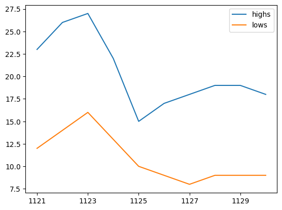

```python
temps.plot.line()
```

```python
# let's add mm_rain as a third column

temps['mm_rain'] = [0, 0, 1, 2, 1, 0, 0, 0, 0, 0]
temps
```

|  | highs | lows | mm_rain |
| --- | --- | --- | --- |
| 1121 | 23 | 12 | 0 |
| 1122 | 26 | 14 | 0 |
| 1123 | 27 | 16 | 1 |
| 1124 | 22 | 13 | 2 |
| 1125 | 15 | 10 | 1 |
| 1126 | 17 | 9 | 0 |
| 1127 | 18 | 8 | 0 |
| 1128 | 19 | 9 | 0 |
| 1129 | 19 | 9 | 0 |
| 1130 | 18 | 9 | 0 |

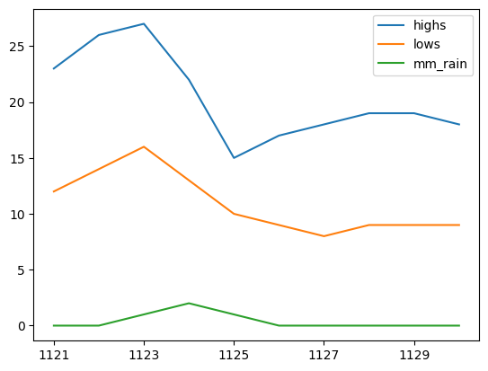

```python
temps.plot.line()
```

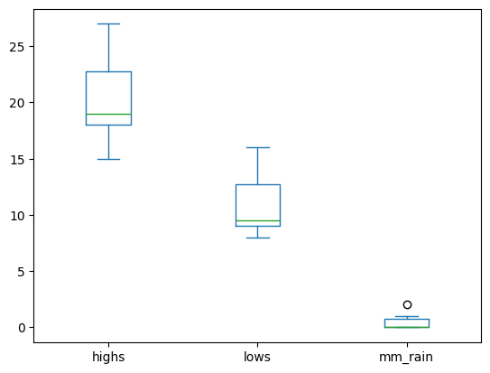

```python
temps.plot.box()
```

```python
# 1 inch = 2.54 cm
# 1 inch = 25.4 mm

temps['inches_rain'] = temps['mm_rain'] / 25.4
temps
```

|  | highs | lows | mm_rain | inches_rain |
| --- | --- | --- | --- | --- |
| 1121 | 23 | 12 | 0 | 0.00000 |
| 1122 | 26 | 14 | 0 | 0.00000 |
| 1123 | 27 | 16 | 1 | 0.03937 |
| 1124 | 22 | 13 | 2 | 0.07874 |
| 1125 | 15 | 10 | 1 | 0.03937 |
| 1126 | 17 | 9 | 0 | 0.00000 |
| 1127 | 18 | 8 | 0 | 0.00000 |
| 1128 | 19 | 9 | 0 | 0.00000 |
| 1129 | 19 | 9 | 0 | 0.00000 |
| 1130 | 18 | 9 | 0 | 0.00000 |

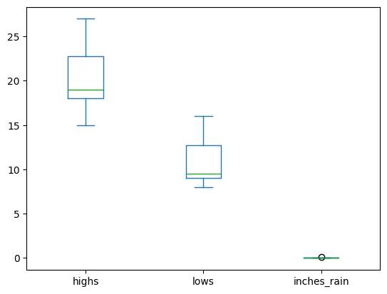

```python
temps[['highs', 'lows', 'inches_rain']].plot.box()
```

```
highs             Axes(0.125,0.11;0.227941x0.77)
lows           Axes(0.398529,0.11;0.227941x0.77)
inches_rain    Axes(0.672059,0.11;0.227941x0.77)
dtype: object
```

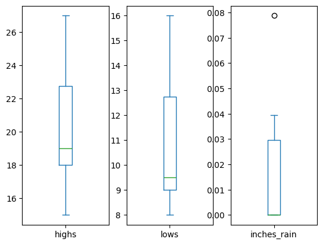

```python
# we can say subplots=True to get each of them on their own vertical axis

temps[['highs', 'lows', 'inches_rain']].plot.box(subplots=True)
```

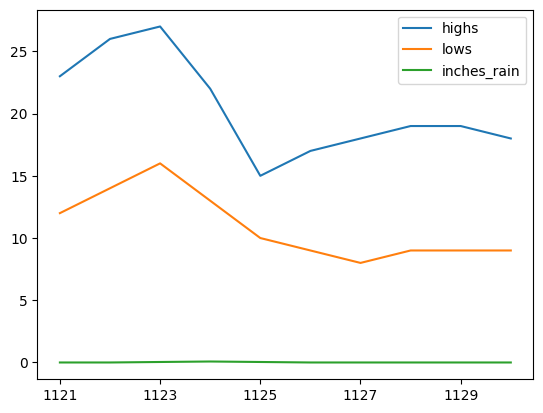

```python
temps[['highs', 'lows', 'inches_rain']].plot.line()
```

```
array([<Axes: ylabel='highs'>, <Axes: ylabel='lows'>], dtype=object)
```

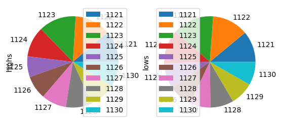

```python
temps[['highs', 'lows']].plot.pie(subplots=True)
```

```python
temps[['highs', 'lows']].value_counts()
```

```
highs  lows
19     9       2
15     10      1
17     9       1
18     8       1
       9       1
22     13      1
23     12      1
26     14      1
27     16      1
Name: count, dtype: int64
```

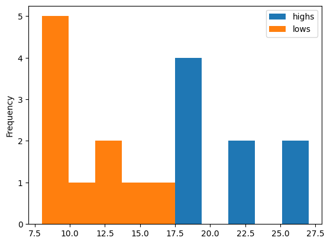

```python
# we can have historgrams from more than one columns, but...

temps[['highs', 'lows']].plot.hist()
```

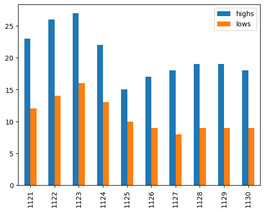

```python
temps[['highs', 'lows']].plot.bar()
```

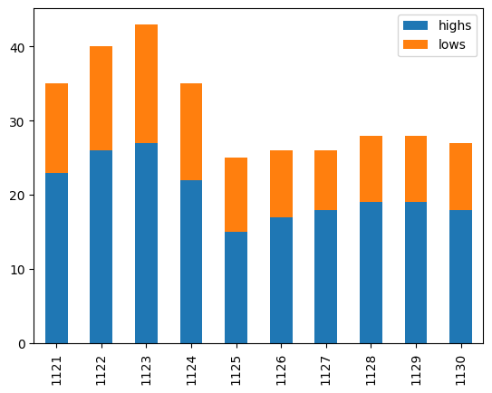

```python
# sometimes, each column in the data frame contains part of the information
# e.g., price + tax.  We can ask for plot.bar to combine these into a single
# bar, showing the distinction between each portion as a different color
# this is known as a "stacked" bar plot

temps[['highs', 'lows']].plot.bar(stacked=True)
```

Warning: If you have a very large data frame, then it's fine to do a boxplot or a histogram. After you use `value_counts`, it's fine to use `.plot.pie`. But don't create either a line or bar plot with a huge number of records.

# Exercises with data frame plotting

1. Get the first 30 records from one of the taxi data sets. Create a stacked bar plot with the various parts of the fare. (Don't use `total_fare`, but do use the fare, tip, tolls, and other things that look fare-ish. Based on the bars you see, are people right that their taxi expenses have gone up a great deal because of the high tax on taxis.
2. Show, from all of the taxi records, a histogram of how far people went.
3. Show, from all of the taxi records, a box plot of the distance people went.
4. What if you show a box plot of both distance and total amount?

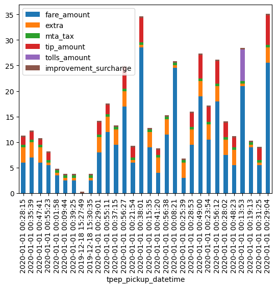

```python
(
    df
    .iloc[:30]
    [['fare_amount', 'extra', 'mta_tax', 'tip_amount', 'tolls_amount', 'improvement_surcharge']]
    .plot.bar(stacked=True)
)
```

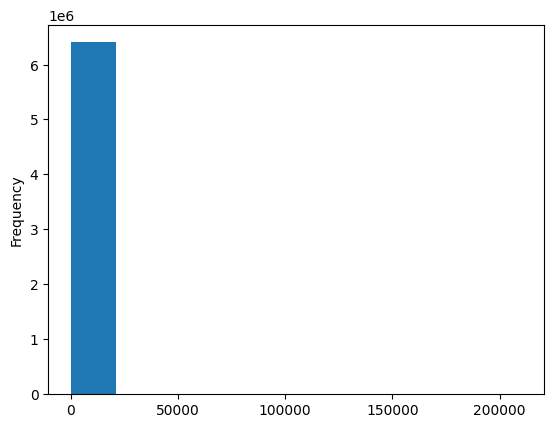

```python
# Show, from all of the taxi records, a histogram of how far people went.

df['trip_distance'].plot.hist()
```

```python
df['trip_distance'].describe()
```

```
count    6.405008e+06
mean     2.929644e+00
std      8.315911e+01
min     -3.062000e+01
25%      9.600000e-01
50%      1.600000e+00
75%      2.930000e+00
max      2.102401e+05
Name: trip_distance, dtype: float64
```

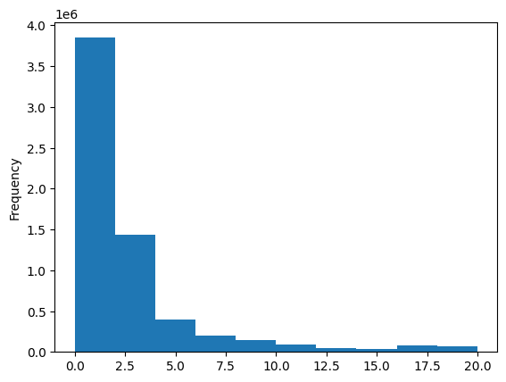

```python
(
    df
    .loc[lambda df_: df_['trip_distance'] < 20]
    .loc[lambda df_: df_['trip_distance'] >= 0]
    ['trip_distance']
    .plot.hist()
)
```

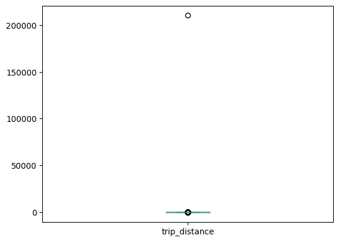

```python
# Show, from all of the taxi records, a box plot of the distance people went.

df['trip_distance'].plot.box()
```

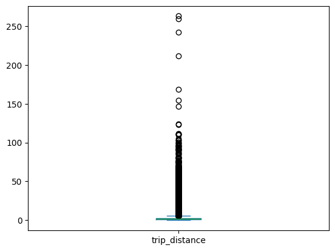

```python
(
    df
    .loc[lambda df_: df_['trip_distance'] < 1000]
    .loc[lambda df_: df_['trip_distance'] >= 0]
    ['trip_distance']
    .plot.box()
)
```

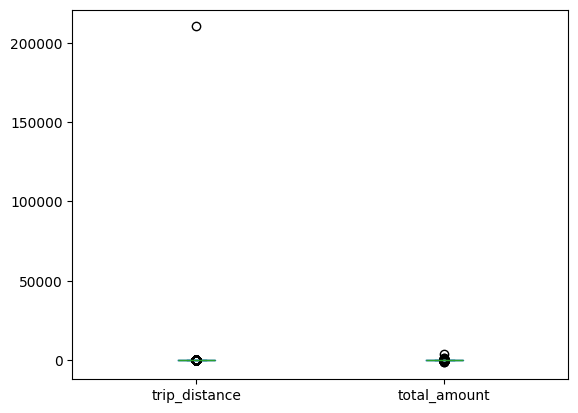

```python
# What if you show a box plot of both distance and total amount?

df[['trip_distance', 'total_amount']].plot.box()
```

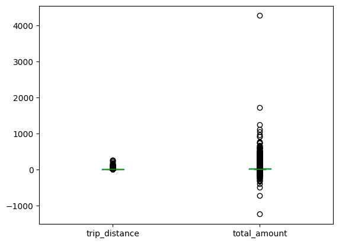

```python
(
    df
    .loc[lambda df_: df_['trip_distance'] < 1000]
    .loc[lambda df_: df_['trip_distance'] >= 0]
    [['trip_distance', 'total_amount']]
    .plot.box()
)
```

```
trip_distance       Axes(0.125,0.11;0.352273x0.77)
total_amount     Axes(0.547727,0.11;0.352273x0.77)
dtype: object
```

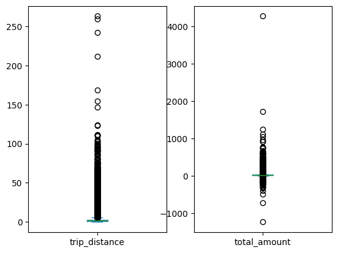

```python
(
    df
    .loc[lambda df_: df_['trip_distance'] < 1000]
    .loc[lambda df_: df_['trip_distance'] >= 0]
    [['trip_distance', 'total_amount']]
    .plot.box(subplots=True)
)
```

# Next up

- Scatterplots
- Query efficiency
- PyArrow

Resume at 13:35 Paris time

Survey link: https://app.performitiv.com/fv2/cisco/ceoevt/VC00507684

# Scatterplots

So far, the plots that we've done have been for series or for a data frame as a collection of series. But none of the plots really take into account the depth of understanding we can get from a data frame as 2D data.

Scatterplots are the big exception. We tell Pandas which column in a data frame should be used as the `x` value for each point, and which column should be used for the `y` value. It plots all of those dots on a graph.

```python
temps
```

|  | highs | lows | mm_rain | inches_rain |
| --- | --- | --- | --- | --- |
| 1121 | 23 | 12 | 0 | 0.00000 |
| 1122 | 26 | 14 | 0 | 0.00000 |
| 1123 | 27 | 16 | 1 | 0.03937 |
| 1124 | 22 | 13 | 2 | 0.07874 |
| 1125 | 15 | 10 | 1 | 0.03937 |
| 1126 | 17 | 9 | 0 | 0.00000 |
| 1127 | 18 | 8 | 0 | 0.00000 |
| 1128 | 19 | 9 | 0 | 0.00000 |
| 1129 | 19 | 9 | 0 | 0.00000 |
| 1130 | 18 | 9 | 0 | 0.00000 |

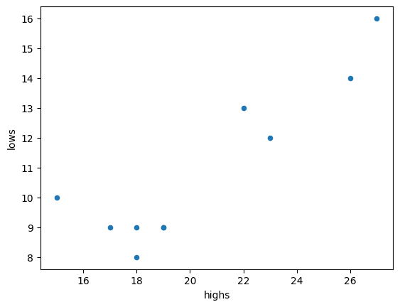

```python
temps.plot.scatter(x='highs', y='lows')
```

```python
# we can see this without a plot, using numbers, by calculating the correlation
# the .corr method on a data frame will show how much the columns correlate with one another
# -1 == perfect negative correlation, +1 == perfect positive correlation, 0 == no correlation at all

temps.corr()
```

|  | highs | lows | mm_rain | inches_rain |
| --- | --- | --- | --- | --- |
| highs | 1.000000 | 0.894648 | 0.177028 | 0.177028 |
| lows | 0.894648 | 1.000000 | 0.497085 | 0.497085 |
| mm_rain | 0.177028 | 0.497085 | 1.000000 | 1.000000 |
| inches_rain | 0.177028 | 0.497085 | 1.000000 | 1.000000 |

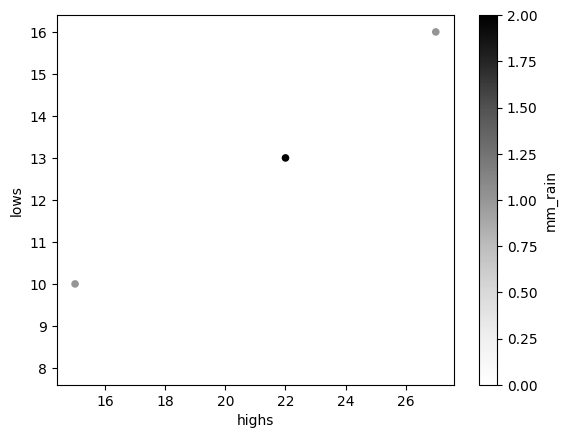

```python
# by default, all of the points are the same colors
# we can, however, ask for a third column to be used in deciding how to color the points

# Pandas will look at the range of values for that third column, and divide it up into different colors
# we specify which column to use with "c"

temps.plot.scatter(x='highs', y='lows', c='mm_rain')
```

[output not shown]

[output cut: 18 more lines]

[output not shown]

[figure not shown]

```python
# to avoid the black-gray-white colormap, we have to specify one
# we do that with "colormap" as a keyword argument, passing a string

temps.plot.scatter(x='highs', y='lows', c='mm_rain', colormap='asdfsafafa')
```

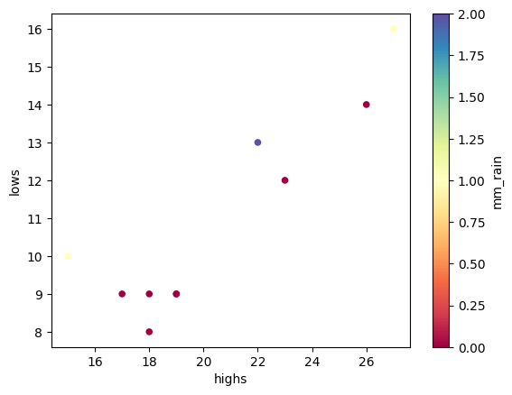

```python
# I'm going to use "Spectral" as a colormap

temps.plot.scatter(x='highs', y='lows', c='mm_rain', colormap='Spectral')
```

```python
temps.corr()
```

|  | highs | lows | mm_rain | inches_rain |
| --- | --- | --- | --- | --- |
| highs | 1.000000 | 0.894648 | 0.177028 | 0.177028 |
| lows | 0.894648 | 1.000000 | 0.497085 | 0.497085 |
| mm_rain | 0.177028 | 0.497085 | 1.000000 | 1.000000 |
| inches_rain | 0.177028 | 0.497085 | 1.000000 | 1.000000 |

It would be nice to get a scatterplot of all possible row-column combinations, then I can see more easily what correlations exist.

We can do this with `scatter_matrix`!

```
array([[<Axes: xlabel='highs', ylabel='highs'>,
        <Axes: xlabel='lows', ylabel='highs'>,
        <Axes: xlabel='mm_rain', ylabel='highs'>,
        <Axes: xlabel='inches_rain', ylabel='highs'>],
       [<Axes: xlabel='highs', ylabel='lows'>,
        <Axes: xlabel='lows', ylabel='lows'>,
        <Axes: xlabel='mm_rain', ylabel='lows'>,
        <Axes: xlabel='inches_rain', ylabel='lows'>],
       [<Axes: xlabel='highs', ylabel='mm_rain'>,
        <Axes: xlabel='lows', ylabel='mm_rain'>,
        <Axes: xlabel='mm_rain', ylabel='mm_rain'>,
        <Axes: xlabel='inches_rain', ylabel='mm_rain'>],
       [<Axes: xlabel='highs', ylabel='inches_rain'>,
        <Axes: xlabel='lows', ylabel='inches_rain'>,
        <Axes: xlabel='mm_rain', ylabel='inches_rain'>,
        <Axes: xlabel='inches_rain', ylabel='inches_rain'>]], dtype=object)
```

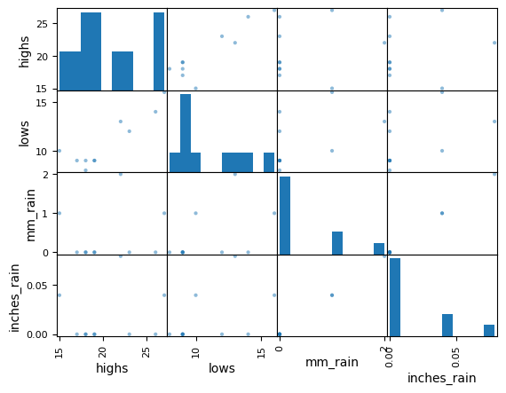

```python
from pandas.plotting import scatter_matrix

scatter_matrix(temps)
```

# Exercise: Scatterplots

1. Load the Olympic data into a data frame. We're only interested in the Height, Weight, Year, Sport, and Medal columns.
2. Show a scatterplot comparing Height and Weight across all sports, colorizing based on year.
3. Show a scatterplot comparing Height and Weight only for Basketball, colorizing based on year. Choose a different colormap, and see if it makes things clearer.
4. Show a scatterplot comparing Height and Weight only for Gymnastics, colorizing based on year. Again, try a different colormap.
5. Rerun the previous two, keeping only those people who have won a medal. Do the plots look different?

```python
df = pd.read_csv('/Users/reuven/Courses/Current/Data/olympic_athlete_events.csv',
                 usecols=['Height', 'Weight', 'Year', 'Sport', 'Medal'])
```

```python
df.shape
```

```
(271116, 5)
```

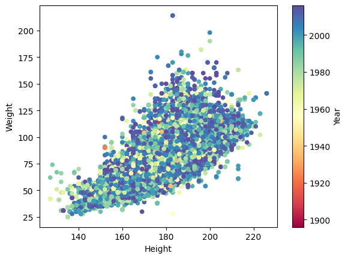

```python
# Show a scatterplot comparing Height and Weight across all sports, colorizing based on year.

df.plot.scatter(x='Height', y='Weight', c='Year', colormap='Spectral')
```

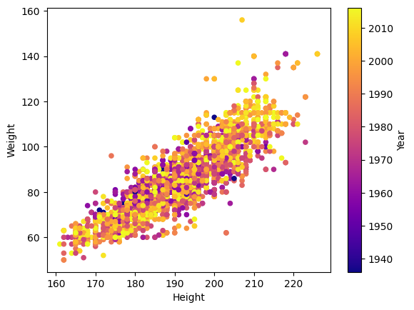

```python
# Show a scatterplot comparing Height and Weight only for Basketball, colorizing based on year. Choose a different colormap, and see if it makes things clearer.

(
    df
    .loc[lambda df_: df_['Sport'] == 'Basketball']
    .plot.scatter(x='Height', y='Weight', c='Year', colormap='plasma')
)
```

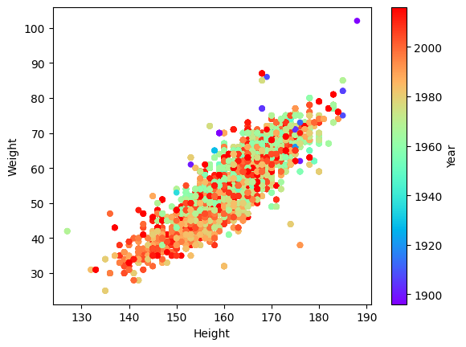

```python
# Show a scatterplot comparing Height and Weight only for Gymnastics, colorizing based on year. Again, try a different colormap.

(
    df
    .loc[lambda df_: df_['Sport'] == 'Gymnastics']
    .plot.scatter(x='Height', y='Weight', c='Year', colormap='rainbow')
)
```

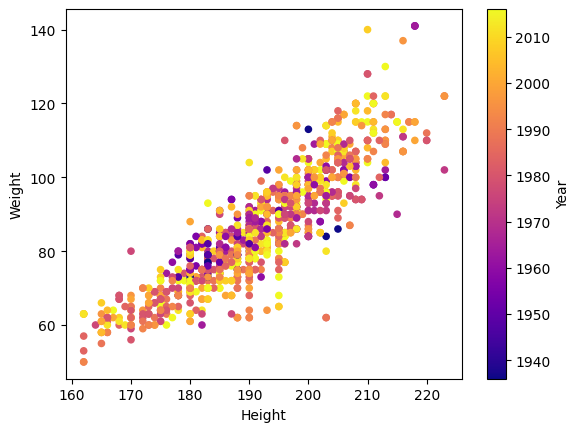

```python
# Rerun the previous two, keeping only those people who have won a medal. Do the plots look different?

(
    df
    .dropna(subset='Medal')
    .loc[lambda df_: df_['Sport'] == 'Basketball']
    .plot.scatter(x='Height', y='Weight', c='Year', colormap='plasma')
)
```

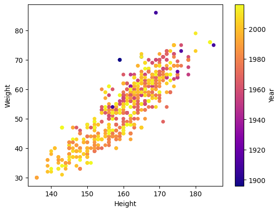

```python
(
    df
    .dropna(subset='Medal')
    .loc[lambda df_: df_['Sport'] == 'Gymnastics']
    .plot.scatter(x='Height', y='Weight', c='Year', colormap='plasma')
)
```

# Query efficiency

If we want our queries to run quickly, the best way to achieve that is to cut down on how much memory our data uses:

- Reduce the size of our data frame (removing rows/columns)
- Reduce the size of the dtypes
- Use some Pandas tricks to reduce the sizes of strings, in particular with categories

# Reducing the size of our data frame

This is the biggest and best thing you can do to improve the speed of your query:

- If there are rows that are bad, or that you can't use, remove them
- If there are columns that you aren't going to use, either don't load them, or drop them

You can always use the `drop` method to remove a row or column:

- You can pass either one index/column name, and then pass `axis='rows'` or `axis='columns'`
- Or you can pass `rows=` or `columns=` and then pass a list of strings, for those

As with so many things in Pandas, `drop` doesn't really remove the row/column, but returns a new data frame without them.

But you can also use `usecols` when you load data, and specify which columns you want.

It's fine (even great) to run `drop` on the newly loaded data, to remove rows you don't need. This is needed, because you can specify `usecols` and ignore certain columns. But there's no way to say which rows you want to ignore.

```python
filename = '/Users/reuven/Courses/Current/Data/nyc-parking-violations-2020.csv'

df = pd.read_csv(filename, low_memory=False)
```

```python
df.shape
```

```
(12495734, 43)
```

```python
!ls -lh $filename
```

```
-rw-r--r-- 1 reuven staff 2.2G Jul  5  2021 /Users/reuven/Courses/Current/Data/nyc-parking-violations-2020.csv
```

```python
df.head()
```

|  | Summons Number | Plate ID | Registration State | Plate Type | Issue Date | Violation Code | Vehicle Body Type | Vehicle Make | Issuing Agency | Street Code1 | ... | Vehicle Color | Unregistered Vehicle? | Vehicle Year | Meter Number | Feet From Curb | Violation Post Code | Violation Description | No Standing or Stopping Violation | Hydrant Violation | Double Parking Violation |
| --- | --- | --- | --- | --- | --- | --- | --- | --- | --- | --- | --- | --- | --- | --- | --- | --- | --- | --- | --- | --- | --- |
| 0 | 1477633194 | J58JKX | NJ | PAS | 05/08/1972 12:00:00 AM | 16 | SDN | HONDA | P | 8730 | ... | BK | 0.0 | 0 | - | 0 | NaN | NaN | NaN | NaN | NaN |
| 1 | 1449715424 | KRE6058 | PA | PAS | 08/29/1977 12:00:00 AM | 98 | SUBN | ME/BE | P | 86530 | ... | BLK | 0.0 | 0 | - | 0 | NaN | NaN | NaN | NaN | NaN |
| 2 | 1455779155 | 444326R | NJ | PAS | 10/03/1988 12:00:00 AM | 20 | SDN | LEXUS | P | 27030 | ... | BLACK | 0.0 | 0 | - | 0 | NaN | NaN | NaN | NaN | NaN |
| 3 | 1458800908 | F728330 | OH | PAS | 01/03/1990 12:00:00 AM | 21 | SDN | CHEVR | P | 33030 | ... | NaN | 0.0 | 0 | - | 0 | NaN | NaN | NaN | NaN | NaN |
| 4 | 1466038676 | FMY9090 | NY | PAS | 02/14/1990 12:00:00 AM | 21 | SUBN | JEEP | S | 45130 | ... | GREY | 0.0 | 2015 | - | 0 | NaN | NaN | NaN | NaN | NaN |

5 rows × 43 columns

```python
df['Vehicle Color'].value_counts().head(20)
```

```
Vehicle Color
WH       2344858
GY       2307704
BK       2066374
WHITE    1061234
BL        775124
RD        483298
BLACK     465110
GREY      306787
BROWN     292348
SILVE     191477
GR        182929
BLUE      178298
RED       161693
TN        120576
BR        102204
YW         98700
BLK        91539
OTHER      60245
GREEN      58765
GL         54851
Name: count, dtype: int64
```

```python
df.columns
```

```
Index(['Summons Number', 'Plate ID', 'Registration State', 'Plate Type',
       'Issue Date', 'Violation Code', 'Vehicle Body Type', 'Vehicle Make',
       'Issuing Agency', 'Street Code1', 'Street Code2', 'Street Code3',
       'Vehicle Expiration Date', 'Violation Location', 'Violation Precinct',
       'Issuer Precinct', 'Issuer Code', 'Issuer Command', 'Issuer Squad',
       'Violation Time', 'Time First Observed', 'Violation County',
       'Violation In Front Of Or Opposite', 'House Number', 'Street Name',
       'Intersecting Street', 'Date First Observed', 'Law Section',
       'Sub Division', 'Violation Legal Code', 'Days Parking In Effect',
       'From Hours In Effect', 'To Hours In Effect', 'Vehicle Color',
       'Unregistered Vehicle?', 'Vehicle Year', 'Meter Number',
       'Feet From Curb', 'Violation Post Code', 'Violation Description',
       'No Standing or Stopping Violation', 'Hydrant Violation',
       'Double Parking Violation'],
      dtype='object')
```

```python
df['Feet From Curb'].mean()
```

```
np.float64(0.08923549428949112)
```

```python
df = pd.read_csv(filename, low_memory=False,
                usecols=['Plate ID', 'Vehicle Color','Feet From Curb', 'Violation Code'])
```

```python
df['Feet From Curb'].dtype
```

```
dtype('int64')
```

```python
df['Feet From Curb'].describe()
```

```
count    1.249573e+07
mean     8.923549e-02
std      7.074554e-01
min      0.000000e+00
25%      0.000000e+00
50%      0.000000e+00
75%      0.000000e+00
max      1.600000e+01
Name: Feet From Curb, dtype: float64
```

```python
df.shape[0]  # how many rows?
```

```
12495734
```

```python
df.shape[0] * 7   # save 87 MB of RAM just by using int8
```

```
87470138
```

```python
df['Violation Code'].describe()
```

```
count    1.249573e+07
mean     3.445436e+01
std      1.762760e+01
min      0.000000e+00
25%      2.100000e+01
50%      3.600000e+01
75%      3.800000e+01
max      9.900000e+01
Name: Violation Code, dtype: float64
```

```python
df = pd.read_csv(filename, low_memory=False,
                 dtype={'Feet From Curb':np.int8,
                       'Violation Code':np.int8},
                usecols=['Plate ID', 'Vehicle Color','Feet From Curb', 'Violation Code'])
```

```python
df.dtypes
```

```
Plate ID          object
Violation Code      int8
Vehicle Color     object
Feet From Curb      int8
dtype: object
```

```python
df = pd.read_csv(filename,
                 dtype={'Feet From Curb':np.int8,
                        'Plate ID':str,
                        'Vehicle Color':str,
                       'Violation Code':np.int8},
                usecols=['Plate ID', 'Vehicle Color','Feet From Curb', 'Violation Code'])
```

```python
df.dtypes
```

```
Plate ID          object
Violation Code      int8
Vehicle Color     object
Feet From Curb      int8
dtype: object
```

When Pandas can't turn values into integers or floats, it treats them as strings -- as Python strings.

```python
df = DataFrame(np.random.randint(0, 1000, [3,4]))
```

```python
df.info()
```

```
<class 'pandas.core.frame.DataFrame'>
RangeIndex: 3 entries, 0 to 2
Data columns (total 4 columns):
 #   Column  Non-Null Count  Dtype
---  ------  --------------  -----
 0   0       3 non-null      int64
 1   1       3 non-null      int64
 2   2       3 non-null      int64
 3   3       3 non-null      int64
dtypes: int64(4)
memory usage: 228.0 bytes
```

```python
import numpy as np
from pandas import DataFrame

df = DataFrame(np.random.randint(0, 1000, [3,4]),
              index=list('abc'),
              columns=list('wxyz'))
```

```python
df.info()
```

```
<class 'pandas.core.frame.DataFrame'>
Index: 3 entries, a to c
Data columns (total 4 columns):
 #   Column  Non-Null Count  Dtype
---  ------  --------------  -----
 0   w       3 non-null      int64
 1   x       3 non-null      int64
 2   y       3 non-null      int64
 3   z       3 non-null      int64
dtypes: int64(4)
memory usage: 120.0+ bytes
```

The moment that we have strings in a data frame, they're stored in *Python* memory, not in NumPy memory. This means that for Pandas to know how much memory they use, it needs to iterate over those strings and get their sizes. This can take a long time, so Pandas doesn't do it. It tells us how much memory is being used by the *pointers* in NumPy to the Python strings.

```python
df.index
```

```
Index(['a', 'b', 'c'], dtype='object')
```

```python
df.index = ['a', 'b', 'abcdefghijklmnopqrstuvwxyz' * 1_000_000]
```

```python
df['s'] = ['a', 'b', 'abcdefghijklmnopqrstuvwxyz' * 1_000_000]
```

```python
df
```

|  | w | x | y | z | s |
| --- | --- | --- | --- | --- | --- |
| a | 749 | 583 | 359 | 72 | a |
| b | 723 | 472 | 713 | 73 | b |
| c | 198 | 815 | 137 | 569 | abcdefghijklmnopqrstuvwxyzabcdefghijklmnopqrst... |

```python
df.info()
```

```
<class 'pandas.core.frame.DataFrame'>
Index: 3 entries, a to c
Data columns (total 5 columns):
 #   Column  Non-Null Count  Dtype
---  ------  --------------  -----
 0   w       3 non-null      int64
 1   x       3 non-null      int64
 2   y       3 non-null      int64
 3   z       3 non-null      int64
 4   s       3 non-null      object
dtypes: int64(4), object(1)
memory usage: 144.0+ bytes
```

```python
# how can I get an accurate reading of the memory usage?
# we have to pass memory_usage='deep' to info

df.info(memory_usage='deep')
```

```
<class 'pandas.core.frame.DataFrame'>
Index: 3 entries, a to c
Data columns (total 5 columns):
 #   Column  Non-Null Count  Dtype
---  ------  --------------  -----
 0   w       3 non-null      int64
 1   x       3 non-null      int64
 2   y       3 non-null      int64
 3   z       3 non-null      int64
 4   s       3 non-null      object
dtypes: int64(4), object(1)
memory usage: 24.8 MB
```

What if our data frame has a column in which the values are strings that often repeat themselves?

If we were in a programming language, we would use an enum or the like to assign an integer to each string, and then use the enums instead of the strings. That would save a lot of memory.

Pandas provides us with exactly this sort of thing, known as a "category." If you turn a series into a type "category", it works just like strings, and handles all of the `.str` methods. But it uses far less memory.

```python
filename = '/Users/reuven/Courses/Current/Data/nyc-parking-violations-2020.csv'

df = pd.read_csv(filename,
                 dtype={'Feet From Curb':np.int8,
                        'Plate ID':str,
                        'Vehicle Color':str,
                       'Violation Code':np.int8},
                usecols=['Plate ID', 'Vehicle Color','Feet From Curb', 'Violation Code'])
```

```python
df.info(memory_usage='deep')
```

```
<class 'pandas.core.frame.DataFrame'>
RangeIndex: 12495734 entries, 0 to 12495733
Data columns (total 4 columns):
 #   Column          Dtype
---  ------          -----
 0   Plate ID        object
 1   Violation Code  int8
 2   Vehicle Color   object
 3   Feet From Curb  int8
dtypes: int8(2), object(2)
memory usage: 1.3 GB
```

```python
# let's turn the "Vehicle Color" column into a category

df['Vehicle Color'] = df['Vehicle Color'].astype('category')
```

```python
df.dtypes
```

```
Plate ID            object
Violation Code        int8
Vehicle Color     category
Feet From Curb        int8
dtype: object
```

```python
df.info(memory_usage='deep')
```

```
<class 'pandas.core.frame.DataFrame'>
RangeIndex: 12495734 entries, 0 to 12495733
Data columns (total 4 columns):
 #   Column          Dtype
---  ------          -----
 0   Plate ID        object
 1   Violation Code  int8
 2   Vehicle Color   category
 3   Feet From Curb  int8
dtypes: category(1), int8(2), object(1)
memory usage: 713.8 MB
```

```python
df['Plate ID'].value_counts()
```

```
Plate ID
BLANKPLATE    8882
2704819       1535
86107MM       1429
2703289       1364
NS            1189
              ...
DVV1033          1
JCX9668          1
BXU5368          1
HFS8627          1
T64528C          1
Name: count, Length: 3245467, dtype: int64
```

```python
df['Plate ID'] = df['Plate ID'].astype('category')
```

```python
df.info(memory_usage='deep')
```

```
<class 'pandas.core.frame.DataFrame'>
RangeIndex: 12495734 entries, 0 to 12495733
Data columns (total 4 columns):
 #   Column          Dtype
---  ------          -----
 0   Plate ID        category
 1   Violation Code  int8
 2   Vehicle Color   category
 3   Feet From Curb  int8
dtypes: category(2), int8(2)
memory usage: 397.3 MB
```

# Exercise: Category improvements

1. Load the Olympic data set, and choose some columns to turn into categories. How much memory usage can you reduce by doing that?
2. If there are any numeric columns that you can reduce in size by using a smaller dtype, try that, as well.

```python
df = pd.read_csv('/Users/reuven/Courses/Current/Data/olympic_athlete_events.csv')

df.head()
```

|  | ID | Name | Sex | Age | Height | Weight | Team | NOC | Games | Year | Season | City | Sport | Event | Medal |
| --- | --- | --- | --- | --- | --- | --- | --- | --- | --- | --- | --- | --- | --- | --- | --- |
| 0 | 1 | A Dijiang | M | 24.0 | 180.0 | 80.0 | China | CHN | 1992 Summer | 1992 | Summer | Barcelona | Basketball | Basketball Men's Basketball | NaN |
| 1 | 2 | A Lamusi | M | 23.0 | 170.0 | 60.0 | China | CHN | 2012 Summer | 2012 | Summer | London | Judo | Judo Men's Extra-Lightweight | NaN |
| 2 | 3 | Gunnar Nielsen Aaby | M | 24.0 | NaN | NaN | Denmark | DEN | 1920 Summer | 1920 | Summer | Antwerpen | Football | Football Men's Football | NaN |
| 3 | 4 | Edgar Lindenau Aabye | M | 34.0 | NaN | NaN | Denmark/Sweden | DEN | 1900 Summer | 1900 | Summer | Paris | Tug-Of-War | Tug-Of-War Men's Tug-Of-War | Gold |
| 4 | 5 | Christine Jacoba Aaftink | F | 21.0 | 185.0 | 82.0 | Netherlands | NED | 1988 Winter | 1988 | Winter | Calgary | Speed Skating | Speed Skating Women's 500 metres | NaN |

```python
df.dtypes
```

```
ID          int64
Name       object
Sex        object
Age       float64
Height    float64
Weight    float64
Team       object
NOC        object
Games      object
Year        int64
Season     object
City       object
Sport      object
Event      object
Medal      object
dtype: object
```

```python
(
    df
    .drop(columns=['ID', 'Age', 'Height', 'Weight', 'Year'])
    .describe()
)
```

|  | Name | Sex | Team | NOC | Games | Season | City | Sport | Event | Medal |
| --- | --- | --- | --- | --- | --- | --- | --- | --- | --- | --- |
| count | 271116 | 271116 | 271116 | 271116 | 271116 | 271116 | 271116 | 271116 | 271116 | 39783 |
| unique | 134732 | 2 | 1184 | 230 | 51 | 2 | 42 | 66 | 765 | 3 |
| top | Robert Tait McKenzie | M | United States | USA | 2000 Summer | Summer | London | Athletics | Football Men's Football | Gold |
| freq | 58 | 196594 | 17847 | 18853 | 13821 | 222552 | 22426 | 38624 | 5733 | 13372 |

```python
(
    df
    .drop(columns=['ID', 'Age', 'Height', 'Weight', 'Year'])
    .describe()
    .columns
)
```

```
Index(['Name', 'Sex', 'Team', 'NOC', 'Games', 'Season', 'City', 'Sport',
       'Event', 'Medal'],
      dtype='object')
```

```python
df.info(memory_usage='deep')
```

```
<class 'pandas.core.frame.DataFrame'>
RangeIndex: 271116 entries, 0 to 271115
Data columns (total 15 columns):
 #   Column  Non-Null Count   Dtype
---  ------  --------------   -----
 0   ID      271116 non-null  int64
 1   Name    271116 non-null  object
 2   Sex     271116 non-null  object
 3   Age     261642 non-null  float64
 4   Height  210945 non-null  float64
 5   Weight  208241 non-null  float64
 6   Team    271116 non-null  object
 7   NOC     271116 non-null  object
 8   Games   271116 non-null  object
 9   Year    271116 non-null  int64
 10  Season  271116 non-null  object
 11  City    271116 non-null  object
 12  Sport   271116 non-null  object
 13  Event   271116 non-null  object
 14  Medal   39783 non-null   object
dtypes: float64(3), int64(2), object(10)
memory usage: 158.9 MB
```

```python
for one_column in ['Name', 'Sex', 'Team', 'NOC', 'Games', 'Season',
                   'City', 'Sport','Event', 'Medal']:
    df[one_column] = df[one_column].astype('category')
```

```python
df.info(memory_usage='deep')
```

```
<class 'pandas.core.frame.DataFrame'>
RangeIndex: 271116 entries, 0 to 271115
Data columns (total 15 columns):
 #   Column  Non-Null Count   Dtype
---  ------  --------------   -----
 0   ID      271116 non-null  int64
 1   Name    271116 non-null  category
 2   Sex     271116 non-null  category
 3   Age     261642 non-null  float64
 4   Height  210945 non-null  float64
 5   Weight  208241 non-null  float64
 6   Team    271116 non-null  category
 7   NOC     271116 non-null  category
 8   Games   271116 non-null  category
 9   Year    271116 non-null  int64
 10  Season  271116 non-null  category
 11  City    271116 non-null  category
 12  Sport   271116 non-null  category
 13  Event   271116 non-null  category
 14  Medal   39783 non-null   category
dtypes: category(10), float64(3), int64(2)
memory usage: 27.5 MB
```

```python
df.dtypes
```

```
ID           int64
Name      category
Sex       category
Age        float64
Height     float64
Weight     float64
Team      category
NOC       category
Games     category
Year         int64
Season    category
City      category
Sport     category
Event     category
Medal     category
dtype: object
```

```python
df.groupby('Team')['Height'].mean()
```

```
Team
30. Februar              171.500000
A North American Team           NaN
Acipactli                174.666667
Acturus                         NaN
Afghanistan              170.592593
                            ...
Zambia                   172.828125
Zefyros                  180.000000
Zimbabwe                 173.325175
Zut                             NaN
rn-2                     176.000000
Name: Height, Length: 1184, dtype: float64
```

```python
df.dtypes
```

```
ID           int64
Name      category
Sex       category
Age        float64
Height     float64
Weight     float64
Team      category
NOC       category
Games     category
Year         int64
Season    category
City      category
Sport     category
Event     category
Medal     category
dtype: object
```

```python
df.describe()
```

|  | ID | Age | Height | Weight | Year |
| --- | --- | --- | --- | --- | --- |
| count | 271116.000000 | 261642.000000 | 210945.000000 | 208241.000000 | 271116.000000 |
| mean | 68248.954396 | 25.556898 | 175.338970 | 70.702393 | 1978.378480 |
| std | 39022.286345 | 6.393561 | 10.518462 | 14.348020 | 29.877632 |
| min | 1.000000 | 10.000000 | 127.000000 | 25.000000 | 1896.000000 |
| 25% | 34643.000000 | 21.000000 | 168.000000 | 60.000000 | 1960.000000 |
| 50% | 68205.000000 | 24.000000 | 175.000000 | 70.000000 | 1988.000000 |
| 75% | 102097.250000 | 28.000000 | 183.000000 | 79.000000 | 2002.000000 |
| max | 135571.000000 | 97.000000 | 226.000000 | 214.000000 | 2016.000000 |

```python
df = pd.read_csv('/Users/reuven/Courses/Current/Data/olympic_athlete_events.csv',
                dtype={'ID':np.uint16,
                         'Age':np.float32,
                         'Height':np.float32,
                         'Weight':np.float32,
                         'Year':np.uint16})

for one_column in ['Name', 'Sex', 'Team', 'NOC', 'Games', 'Season',
                   'City', 'Sport','Event', 'Medal']:
    df[one_column] = df[one_column].astype('category')
```

```python
df.info(memory_usage='deep')
```

```
<class 'pandas.core.frame.DataFrame'>
RangeIndex: 271116 entries, 0 to 271115
Data columns (total 15 columns):
 #   Column  Non-Null Count   Dtype
---  ------  --------------   -----
 0   ID      271116 non-null  uint16
 1   Name    271116 non-null  category
 2   Sex     271116 non-null  category
 3   Age     261642 non-null  float32
 4   Height  210945 non-null  float32
 5   Weight  208241 non-null  float32
 6   Team    271116 non-null  category
 7   NOC     271116 non-null  category
 8   Games   271116 non-null  category
 9   Year    271116 non-null  uint16
 10  Season  271116 non-null  category
 11  City    271116 non-null  category
 12  Sport   271116 non-null  category
 13  Event   271116 non-null  category
 14  Medal   39783 non-null   category
dtypes: category(10), float32(3), uint16(2)
memory usage: 21.3 MB
```

What's the problem with turning those columns into ints? The answer: `NaN`. Because `NaN` is a float that cannot be turned into an int, we're stuck with float columns.

What we really want is "nullable types" in Pandas, where we can have an `int` column that contains `NaN`.

You might have noticed that we don't say `isnan`, but rather `isna`. That's because Pandas is (slowly) moving away from `np.nan` and toward `pd.NA`, its own value. We cannot use it with the NumPy types but we *can* use it with the Pandas "extension types." These are wrappers around the NumPy types that are all nullable, thus allowing us to have integers and `pd.NA`, and not switch to floats.

```python
df = pd.read_csv('/Users/reuven/Courses/Current/Data/olympic_athlete_events.csv',
                dtype={'ID':np.uint16,
                         'Age':pd.UInt8Dtype(),
                         'Height':pd.UInt8Dtype(),
                         'Weight':np.float32,
                         'Year':pd.UInt16Dtype()})

for one_column in ['Name', 'Sex', 'Team', 'NOC', 'Games', 'Season',
                   'City', 'Sport','Event', 'Medal']:
    df[one_column] = df[one_column].astype('category')
```

```python
df['Age']
```

```
0         24
1         23
2         24
3         34
4         21
          ..
271111    29
271112    27
271113    27
271114    30
271115    34
Name: Age, Length: 271116, dtype: UInt8
```

```python
df['Age'].sort_values()
```

```
142882      10
252231      11
101378      11
140650      11
237141      11
          ...
270679    <NA>
270774    <NA>
270793    <NA>
270804    <NA>
270805    <NA>
Name: Age, Length: 271116, dtype: UInt8
```

```python
df.info(memory_usage='deep')
```

```
<class 'pandas.core.frame.DataFrame'>
RangeIndex: 271116 entries, 0 to 271115
Data columns (total 15 columns):
 #   Column  Non-Null Count   Dtype
---  ------  --------------   -----
 0   ID      271116 non-null  uint16
 1   Name    271116 non-null  category
 2   Sex     271116 non-null  category
 3   Age     261642 non-null  UInt8
 4   Height  210945 non-null  UInt8
 5   Weight  208241 non-null  float32
 6   Team    271116 non-null  category
 7   NOC     271116 non-null  category
 8   Games   271116 non-null  category
 9   Year    271116 non-null  UInt16
 10  Season  271116 non-null  category
 11  City    271116 non-null  category
 12  Sport   271116 non-null  category
 13  Event   271116 non-null  category
 14  Medal   39783 non-null   category
dtypes: UInt16(1), UInt8(2), category(10), float32(1), uint16(1)
memory usage: 20.5 MB
```

# NumPy is a problem

We've seen that NumPy is great in many ways, but it just wasn't designed for analysis across both rows and columns. Moreover, if we want to share data with other systems, Pandas is in its own world.

Enter Apache Arrow, a library for creating data frames in different programming languages. If you use Arrow, you don't need to implement as much. Plus, you get a whole lot of great features.

PyArrow is the Python wrapper for Arrow. And Pandas, as of now, supports PyArrow both for loading CSV files, and for using its own binary formats (parquet and feather), and (experimentally) for the dtype backend instead of NumPy.

Arrow is great right for a dtype backend (right now) if you stay within one column. But the moment you work with multiple rows and columns, or pull out rows, it falls apart in performance.

1. To load CSV files with Arrow, just say `engine='pyarrow'`

```python
import time
start_time = time.time()
df = pd.read_csv(filename, low_memory=False)
end_time = time.time()

print(f'Total time = {end_time - start_time}')
```

```
Total time = 54.095953941345215
```

```python
import time
start_time = time.time()
df = pd.read_csv(filename, engine='pyarrow')
end_time = time.time()

print(f'Total time = {end_time - start_time}')
```

```
Total time = 12.774458885192871
```

```python
df.dtypes
```

```
Summons Number                         int64
Plate ID                              object
Registration State                    object
Plate Type                            object
Issue Date                            object
Violation Code                         int64
Vehicle Body Type                     object
Vehicle Make                          object
Issuing Agency                        object
Street Code1                           int64
Street Code2                           int64
Street Code3                           int64
Vehicle Expiration Date                int64
Violation Location                   float64
Violation Precinct                     int64
Issuer Precinct                        int64
Issuer Code                            int64
Issuer Command                        object
Issuer Squad                          object
Violation Time                        object
Time First Observed                   object
Violation County                      object
Violation In Front Of Or Opposite     object
House Number                          object
Street Name                           object
Intersecting Street                   object
Date First Observed                    int64
Law Section                            int64
Sub Division                          object
Violation Legal Code                  object
Days Parking In Effect                object
From Hours In Effect                  object
To Hours In Effect                    object
Vehicle Color                         object
Unregistered Vehicle?                float64
Vehicle Year                           int64
Meter Number                          object
Feet From Curb                         int64
Violation Post Code                   object
Violation Description                 object
No Standing or Stopping Violation    float64
Hydrant Violation                    float64
Double Parking Violation             float64
dtype: object
```

```python
# We can use the Arrow binary formats to store our data, and thus load them faster.

df.to_parquet('/tmp/nyc-parking.parquet')  # optimized for disk space
df.to_feather('/tmp/nyc-parking.feather')  # optimized for time
```

```python
!ls -lh /tmp/nyc*
```

```
-rw-r--r-- 1 reuven wheel 1.4G Nov 21 16:12 /tmp/nyc-parking.feather
-rw-r--r-- 1 reuven wheel 379M Nov 21 16:12 /tmp/nyc-parking.parquet
```

```python
import time
start_time = time.time()
df = pd.read_parquet('/tmp/nyc-parking.parquet')
end_time = time.time()

print(f'Total time = {end_time - start_time}')
```

```
Total time = 11.7293701171875
```

```python
import time
start_time = time.time()
df = pd.read_feather('/tmp/nyc-parking.feather')
end_time = time.time()

print(f'Total time = {end_time - start_time}')
```

```
Total time = 9.672590970993042
```

```python
# Third thing that PyArrow gives us is the back-end dtypes

import time
start_time = time.time()
df = pd.read_feather('/tmp/nyc-parking.feather',
                    dtype_backend='pyarrow')
end_time = time.time()

print(f'Total time = {end_time - start_time}')
```

```
Total time = 1.550786018371582
```

```python
df.dtypes
```

```
Summons Number                        int64[pyarrow]
Plate ID                             string[pyarrow]
Registration State                   string[pyarrow]
Plate Type                           string[pyarrow]
Issue Date                           string[pyarrow]
Violation Code                        int64[pyarrow]
Vehicle Body Type                    string[pyarrow]
Vehicle Make                         string[pyarrow]
Issuing Agency                       string[pyarrow]
Street Code1                          int64[pyarrow]
Street Code2                          int64[pyarrow]
Street Code3                          int64[pyarrow]
Vehicle Expiration Date               int64[pyarrow]
Violation Location                   double[pyarrow]
Violation Precinct                    int64[pyarrow]
Issuer Precinct                       int64[pyarrow]
Issuer Code                           int64[pyarrow]
Issuer Command                       string[pyarrow]
Issuer Squad                         string[pyarrow]
Violation Time                       string[pyarrow]
Time First Observed                  string[pyarrow]
Violation County                     string[pyarrow]
Violation In Front Of Or Opposite    string[pyarrow]
House Number                         string[pyarrow]
Street Name                          string[pyarrow]
Intersecting Street                  string[pyarrow]
Date First Observed                   int64[pyarrow]
Law Section                           int64[pyarrow]
Sub Division                         string[pyarrow]
Violation Legal Code                 string[pyarrow]
Days Parking In Effect               string[pyarrow]
From Hours In Effect                 string[pyarrow]
To Hours In Effect                   string[pyarrow]
Vehicle Color                        string[pyarrow]
Unregistered Vehicle?                double[pyarrow]
Vehicle Year                          int64[pyarrow]
Meter Number                         string[pyarrow]
Feet From Curb                        int64[pyarrow]
Violation Post Code                  string[pyarrow]
Violation Description                string[pyarrow]
No Standing or Stopping Violation    double[pyarrow]
Hydrant Violation                    double[pyarrow]
Double Parking Violation             double[pyarrow]
dtype: object
```

```python
df.info()
```

```
<class 'pandas.core.frame.DataFrame'>
RangeIndex: 12495734 entries, 0 to 12495733
Data columns (total 43 columns):
 #   Column                             Dtype
---  ------                             -----
 0   Summons Number                     int64[pyarrow]
 1   Plate ID                           string[pyarrow]
 2   Registration State                 string[pyarrow]
 3   Plate Type                         string[pyarrow]
 4   Issue Date                         string[pyarrow]
 5   Violation Code                     int64[pyarrow]
 6   Vehicle Body Type                  string[pyarrow]
 7   Vehicle Make                       string[pyarrow]
 8   Issuing Agency                     string[pyarrow]
 9   Street Code1                       int64[pyarrow]
```

[output cut: 35 more lines]